# Norwegian Basin Implementation

StrathE2E2

Jack H Laverick Tanguy Genthon Douglas C Spiers Michael R Heath

11 Jul 2025

# Introduction

This document describes the configuration of StrathE2E2 for the Norwegian basin and its parameterisation to enable stationary state fitting for 2010-2070. These represent contrasting periods of environmental conditions.

Volumetric and seabed habitat data define the physical configuration of the system. We regard these as being fixed in time. Similarly, we regard the physiological parameters of the ecology model as being fixed in time. Some of these are set from external data. The remainder are fitted, as detailed here. Changes in the model performance between the different time periods therefore stem from the hydrodynamic, hydro-chemical and fishery driving data. These are detailed in the ecological drivers and fishing fleet sections.

> Department of Mathematics and Statistics, University of Strathclyde, Glasgow, UK.

> E-mail: m.heath@strath.ac.uk

> The code written to support this parameterisation is available on [github](https://github.com/Jack-H-Laverick/MA.NorwegianBasin).

> **WARNING**: This is a working document, subject to update and revision.

# Model Domain

[figure not shown]

Figure 1: The spatial structure of StrathE2E; Ocean volumes and seafloor habitats. StrathE2E is built around a simplified spatial structure which represents shelf seas. These spatial units are connected to each other and to boundaries as shown to the right. The volumes connected to each spatial component are highlighted in blue.

*The perimeter of the model domain is defined by a 600m depth contour and the Norwegian coastline. Open ocean boundaries occur wherever there is no coastline.*

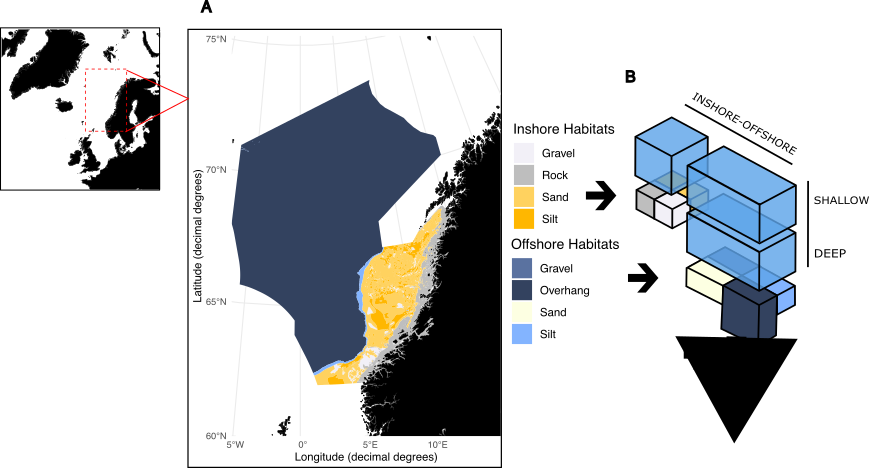

# Fixed Physical

## Background

#### Parameters for relationship between median grain size, sediment porosity and permeability. Permeability is used as the basis for estimating hydraulic conductivity which is a parameter in the representation of sediment processes in the model:

Porosity (proportion by volume of interstitial water) and permeability of each sediment habitat were derived from median grain sizes using empirically-based relationships.

$$log_{10}(porosity) = p_3 + p_4\left(\frac{1}{1+e^{(\frac{-log_{10}(D_{50})-p_1}{p_2})}}\right)$$
D<sub>50</sub> = median grain size (mm); parameters p<sub>1</sub> = -1.227, p<sub>2</sub> = -0.270, p<sub>3</sub> = -0.436, p<sub>4</sub> = 0.366 (Heath et al. 2015)

$$permeability = 10^{p_5}∙D_{50}^{*p_6}$$

where D<sub>50</sub>* = 0.11 ≤ D<sub>50</sub> ≤ 0.50 p<sub>5</sub> = -9.213, p<sub>6</sub> = 4.615 (2015).

These relationships are coded into the StrathE2E2 R-package with the parameters in the csv setup file for the North Sea model. The parameters are probably a reasonable starting point for any future model of a new region. Derivation of the parameters is described in the following text sub-sections.

#### Parameters for in-built relationship between sediment mud content, and slowly degrading (refractory) organic nitrogen content of seabed sediments (see description in this document):

Values for each sediment type derived from parametrised relationships between total organic nitrogen content of sediments (TON%, percent by weight), mud content (mud%, percent by weight) and median grain size (D<sub>50</sub>, mm).

$$mud\% = 10^{p_7}∙𝐷_{50}^{𝑝_8}$$
p<sub>7</sub> = 0.657, p<sub>8</sub> = -0.800

$$TON\% = 10^{𝑝_9}∙mud\%^{𝑝_{10}}$$

p<sub>9</sub> = -1.965, p<sub>10</sub> = 0.590

Proportion of TON estimated to be refractory = 0.9

Table 1: Area-proportions of the inshore and offshore zones and the thicknesses of the water column layers. The sea surface area of the model domain is an estimated 766883.793204946 km<sup>2</sup>.

| Property | Inshore/shallow | Offshore/deep |
| --- | --- | --- |
| Sea-surface area proportion | 0.1911 | 0.8089 |
| Upper layer thickness (m) | 267.1378 | 60.0000 |
| Lower layer thickness (m) | NA | 639.5180 |

We derived the area-proportions of seabed habitat in the inshore and offshore zones from output of the Random Forest model described by Laverick et al. (2022). The model allows for the prediction of a range of seabed data, including the presence of rock, the percentage of mud, sand and gravel fractions in the sediments and the whole–sediment mean grain size. These values are derived from habitat classes used by the Norwegian Geological survey in partnership with the Russian Federal State Unitarian Research and Production Company for Geological Sea Survey (NGU-SEVMORGEO). We assigned the NGU-SEVMORGEO sediment classes as fine, medium, coarse, or absence of sediment habitats within each zone (Figure 2). The actual area of each habitat was then the sum of the areas of each set of assigned cells (Table 2).

Table 2: Area proportions and other characteristics of the 8 seabed habitat classes defined in the model by depth, rock or sediment type. The sea surface area of the model domain is an estimated 766883.793204946 km<sup>2</sup>. Grain size is the median in mm, Permeability in units of m<sup>2</sup>, nitrogen content in %dw.

| Habitat | Sediment | Area Proportion | Grain size | Porosity | Permeability | Nitrogen content |
| --- | --- | --- | --- | --- | --- | --- |
| Inshore - Shallow |  |  |  |  |  |  |
| S0 | None (Rock) | 0.0465 | NA | NA | NA | NA |
| S1 | Fine | 0.0357 | 0.0078 | 0.4429 | 0.0000 | 0.2700 |
| S2 | Medium | 0.0948 | 0.3536 | 0.3939 | 0.0000 | 0.0270 |
| S3 | Coarse | 0.0140 | 11.3137 | 0.3785 | 0.0000 | 0.0000 |
| Offshore - Deep |  |  |  |  |  |  |
| D1 | Fine | 0.0083 | 0.0078 | 0.4787 | 0.0000 | 0.2700 |
| D2 | Medium | 0.0000 | 0.3536 | 0.3890 | 0.0000 | 0.0270 |
| D3 | Coarse | 0.0000 | 11.3137 | 0.3720 | 0.0000 | 0.0000 |
| D0 | None (Overhang) | 0.8006 | NA | NA | NA | NA |

## Sediment porosity

Log-transformed porosity has been shown to have a sigmoidal relationship with log<sub>10</sub>(median grain size) (D<sub>50</sub>, mm) (Wilson et al. 2018):

$$log_{10}(porosity) = p_3 + p_4\left(\frac{1}{1+e^{(\frac{-log_{10}(D_{50})-p_1}{p_2})}}\right)$$

We use this relationship to calculate porosity for sea bed sediments in the Norwegian Sea (Table 2), using an alternative parameterisation to Wilson (Pace et al. 2021). This alternative set of parameters extends the relationship to fine, muddy sediments (Table 3).

Table 3: The four parameters for the function relating sediment porosity to median grain size. From Pace et al. (in review)

| P1 | P2 | P3 | P4 |
| --- | --- | --- | --- |
| -1.035 | -0.314 | -0.435 | 0.302 |

## Hydraulic conductivity

Hydraulic conductivity (H, m.s<sup>-1</sup>) represents the ease with which fluids flow through the particle grain matrix. The related term ‘permeability’ (m<sup>-2</sup>) is a measure of the connectedness of the fluid filled void spaces between the particle grains. Permeability is a function only of the sediment matrix, whilst conductivity is a function of both the sediment and the permeating fluid, in particular the fluid viscosity and density. Hydraulic conductivity is related to permeability by:

$$H = Permeability∙fluid\;density∙\frac{𝑔}{dynamic\;viscosity}$$

where: seawater density = 1027 kg.m<sup>-3</sup> at salinity 35 and temperature 10°C; seawater dynamic viscosity = 1.48 x 10<sup>-3</sup> kg.m<sup>-1</sup>.s<sup>-1</sup> at salinity 35 and temperature 10°C; g = acceleration due to gravity = 9.8 m.s<sup>-1</sup>

Hence, $H = Permeability · 6.8004·10^6$ (m.s<sup>-1</sup> at salinity 35 and temperature 10°C)

Whole sediment permeability can be related to the proportion of sediment classed as mud (D<sub>50</sub> < 62 μm) (Pace et al. 2021). This relationship was used in the production of the Norwegian Basin model (Table 2).

## Sediment organic nitrogen content

The magnitude of the static (refactory) organic nitrogen detritus pool in each sediment type is a required input to the model. The code includes an option to impute values from empirical relationships between total organic nitrogen (TON) and mud content, and between mud content and median grain size. This relationship has been documented in the North Sea implementation of the temperate StrathE2E2 package (M. R. Heath et al. 2021), and is based on sediment data off northeast Scotland.

# Fixed biological

## Configuration parameters

### Assimilation efficiencies for each living guild in the model.

Fixed parameters defining the proportion of ingested mass of food that contributes to new body tissue, after subtracting defecation and the metabolic costs of digestion and synthesis (M. R. Heath 2012).

### Biomass loss rates due to temperature-dependent metabolism for each living resource guild.

Proportion of biomass lost to ammonia per day due to non-feeding related metabolism at a given reference temperature. Rates for individual guilds broadly related to typical body mass of representative species. Temperature dependency following a Q<sub>10</sub> function.

### Q<sub>10</sub> values for temperature dependent processes, and the Q<sub>10</sub> reference temperature.

Separate Q10 values for autotrophic uptake of nutrient, heterotrophic feeding, and heterotrophic metabolism based on literature data.

### Light intensity required to saturate autotrophic nutrient uptake.

Light saturation intensity for nutrient uptake cannot be treated as a fitted value since it is confounded with other uptake parameters. Value estimated from survey of laboratory experiments.

### Annual weight specific fecundities of planktivorous and demersal fish guilds and the two benthos guilds in the model (suspension/deposit feeders and carnivore/scavenge feeders).

Guild-level values derived by surveying the literature.

### Harvestable biomass density threshold for each resource guild.

The living resource guilds in the model represent a mixture of harvestable and non-harvestable species, especially the invertebrate guilds. The density threshold parameter sets a limit for the guild biomass below which the harvestable species are assumed to be exhausted. Values set from analysis of trawl, plankton and benthos survey species biomass compositions.

### Minimum inedible biomass of carnivorous zooplankton.

The carnivorous zooplankton guild is a key component of the food web, predated on by all the fish and top-predators. However it represents an extremely diverse range of fauna many of which are not edible in significant quantities by the guild predators, e.g. scyphomedusae. A minimum edible threshold is set to ensure that the guild as a whole cannot be extirpated by predation. The value is a rough estimate of scyphomedusae biomass.

## Event timing parameters (not fitted)

### Spawning start and end dates for fish

For the fish guilds the dates were obtained from literature survey. The annual weight-specific fecundity is assumed to be shed uniformly between the start and end dates of spawning. Pelagic planktivorous fish in the model are approximated as Norwegian Spring-Spawning herrings (*Clupea harengus*) as it is the major biomass in the region. The spawning dates were calculated from (Garcia et al. 2021) to be between February and March. Demersal fish spawning dates were approximated by the spawning dates of the cod (*Gadus morhua*), saithe (*Pollachius virens*) and haddock (*Melanogrammus aeglefinus*) from (Eikefjord 2023).

### Recruitment start and end dates for fish

Obtained from literature survey. The annual cohort of larvae/juveniles of each fish and benthos guild is assumed to recruit to the settled stage at a uniform daily rate between the start and end dates. Again, the guild **pelagic planktivorous fish** in the model is approximated by Norwegian Spring-Spawning herring. The herring in larval stage, leaves the study area for the Barents Sea for 3-4 years and join the adult population at the end of their wintering (Holst, Røttingen, and Melle 2004). Demersal fish recruitment dates were also approximated by the recruitment dates of the cod (*Gadus morhua*), saithe (*Pollachius virens*) and haddock (*Melanogrammus aeglefinus*) from (Eikefjord 2023).

### Spawning and recruitment start and end dates for benthos guilds

The annual weight-specific fecundity and recruitment for the benthos guilds are assumed to be uniform between the start and end dates. For the **Scavenger and carnivorous benthos** guild, the crab *Cancer pagurus* and the two sea urchins *Echinus esculentus* and *Strongylocentrotus droebachiensis* were elected to obtain timing dates (Bakke 2019; Hamed et al. 2024; James and Siikavuopio 2012). Finally, for the **Suspension/deposit feeding benthos** guild, it was particularly difficult to select reference species in the area and even more finding coherent spawning and recruitment dates. A large number of species have been reported in the area (Buhl-Mortensen, Hodnesdal, and Thorsnes 2015) going from cold water corals like *Desmophyllum pertusum* (formerly *Lophelia pertusa* ), to sponges and to shells. However, few specific dates for spawning were available and, when available, several species had multiple spawning per year which could not be included into the model. The Continuous Plankton Recorder (CPR) had only at this time, data from fish larvae survey so was not usable. We therefore decided to fix the spawning and recruitment dates to the dates of *Desmophyllum pertusum* (Brooke and Järnegren 2013; Järnegren and Kutti 2014).

### Extra-domain stock biomass of migratory, and the proportion invading the domain each year. Start and end dates for the annual invasion, and start and end dates for the emigration. (see description below).

Migratory fish in the Norwegian Sea model are assumed to be Atlantic mackerel and the Blue whiting. The spawning for Atlantic mackerel takes place off southwest Ireland in April and between February and April on the West of the British Isles for the Blue whiting. After spawning, both species rapidly migrate to summer feeding zones thousands of kilometers northwards along the continental shelf edge to the Norwegian and Barents Seas. (Iversen 2004; Bachiller et al. 2016). Some spawning of Atlantic mackerel have been observed in the Norwegian Sea feeding area (dos Santos Schmidt et al. 2024).

For the purposes of the model, we assume that there is no feedback between fishing and environmental conditions in the Norwegian Sea and the biomass and migration patterns of the whole northeast Atlantic mackerel or Blue whiting stock. In this version of StrathE2E2 the timing of immigration and emigration, and the mass influx across the ocean boundary during the annual immigration phase are treated as period-specific external driving data.

Data on the ‘global’ stock of northeast Atlantic mackerel and Blue whiting (wet biomass) are available from stock assessments (W. ICES 2020), and converted to molar nitrogen mass using appropriate conversion ratios (Pedersen et al. 2021). The proportion of the migrating stock entering the Norwegian Sea (Nøttestad et al. 2016; Ekerhovd 2010), and the timing of the inward and outward migrations (Iversen 2002; Payne et al. 2012) are estimated from the literature. A residual proportion of the peak abundance in the North Sea remaining as residents (if any) is estimated from summer trawl survey data. The model setup code calculates the parameters which are needed in the ecology model.These are the only fixed (i.e. non-fitted) ecology model parameters which are period-specific.

Table 4: Biological event timing parameters, constant across the 2011-2070 time period. The data are processed in the model setup to calculate the immigration flux parameters needed in the ecology model.

| Parameter | Value |
| --- | --- |
| Pelagic fish spawning start day | 58 |
| Pelagic fish spawning duration (days) | 21 |
| Pelagic fish recruitment start day | 255 |
| Pelagic fish recruitment duration (days) | 150 |
| Demersal fish spawning start day | 43 |
| Demersal fish spawning duration (days) | 45 |
| Demersal fish recruitment start day | 95 |
| Demersal fish recruitment duration (days) | 30 |
| Filt/dep benthos spawning start day | 20 |
| Filt/dep benthos spawning duration (days) | 50 |
| Filt/dep benthos recruitment start day | 56 |
| Filt/dep benthos recruitment duration (days) | 56 |
| Carn/scav benthos spawning start day | 10 |

Table 4 Continued.

| Parameter | Value |
| --- | --- |
| Carn/scav benthos spawning duration (days) | 110.00 |
| Carn/scav benthos recruitment start day | 240.00 |
| Carn/scav benthos recruitment duration (days) | 90.00 |
| Migratory fish switch (0=off 1=on) | 1.00 |
| Migratory fish ocean biomass (Tonnes wet weight) | 11230000.00 |
| Migratory fish carbon to wet weight (g/g) | 0.12 |
| Model domain sea surface area (km2) | 766883.79 |
| Propn of ocean population entering model domain each year | 0.45 |
| Imigration start day | 91.00 |
| Imigration end day (must be later than start day even if migration disabled) | 270.00 |
| Propn of peak popn in model domain which remains and does not emigrate | 0.20 |
| Emigration start day | 300.00 |
| Emigration end day (must be later than start day even if migration disabled) | 360.00 |

# Ecological drivers

Monthly resolution time-varying physical and chemical driving parameters for the model were derived from a variety of sources:

Details of how these data were processed are given below, supported by the [nemomedusR](https://jack-h-laverick.github.io/nemoRsem/) and [MiMeMo.tools](https://jack-h-laverick.github.io/MiMeMo.tools/) packages.

### NEMO-ERSEM ensemble:

Four different NEMO-ERSEM runs were used to parameterise different versions of the Norwegian Sea implementation of StrathE2E. These four runs are a 2x2 factorial cross of two future projected scenarios (SSP126 and SSP370) with a historical hindcast from 2015, and forcing by two atmospheric models (CNRM and GFDL). In the following sections model output was processed for a 2010-2019 baseline period, and then decadal projections from 2020-2029 until 2060-2069.

### Vertical mixing coefficients between the model layers:

Vertical diffusivity from the NEMO-ERSEM coupled hydro-geochemical model output was interpolated for each grid cell at the 60m boundary depth between the shallow and deep layers of the offshore zone, and the 600m boundary at the deep sea overhang. These values were summarised as monthly averages into period-specific climatological annual cycles of data for decadal periods for all combinations of SSPs and forcings.

### Monthly averaged temperatures for each water column layer:

Derived by monthly averaging values at grid points within the inshore and vertical layers of the offshore zones from the NEMO-ERSEM coupled hydro-geochemical model output, weighted by grid point volumes. Values were summarised into period-specific climatological annual cycles of data.

### Monthly averaged suspended particulate matter (SPM) concentrations (mg.m<sup>-3</sup>) in the shallow zone and the deep zone upper layer:

Monthly averaged values of inorganic suspended particulate matter in sea water are available from the Globcolour project, starting from September 1997. These data are derived from satellite observations using the algorithm of Gohin (2011). Data were downloaded from the ftp server (ftp://ftp.hermes.acri.fr/GLOB/merged/month/). We summarised these values as zonal statistics for the model domain to acquire a climatological annual cycle of data for the 2010-2019 simulation period only.

### Monthly average light attenuation coefficients for the inshore and offshore surface layers:

Light attenuation in open water was parameterised from a linear relationship between the light attenuation coefficient and suspended particulate matter concentration (SPM) (Devlin et al., 2008).

### Monthly averaged daily integrated irradiance at the sea surface (E.m<sup>-2</sup>.d<sup>-1</sup>):

Derived from HadGEM2-ES model output (Jones et al. 2011) which forces the NEMO-ERSEM model run used throughout our implementation. Monthly mean values were summarised into climatological annual cycles of data for decadal periods and NEMO-ERSEM ensembles.

### Monthly averaged daily atmospheric deposition rates of oxidised and reduced nitrogen onto the sea surface in the shallow and deep zones (mMN.m<sup>-2</sup>.d<sup>-1</sup>):

Sourced from the “histsoc” files for a 1901 - 2021 hindcast as monthly averages (Yang and Tian 2022), available from [CDS](https://cds.climate.copernicus.eu/cdsapp#!/dataset/10.24381/cds.f17050d7?tab=overview). Monthly values were summarised into climatological annual cycles of monthly oxidised and reduced nitrogen deposition rates extracted for 2010-2019. ISIMIPb Projections for SSP126 and SSP370 were processed in the same way for decadal periods up to and including the 2060s.

### Monthly averaged, freshwater river inflow rates (expressed as a daily proportion of the receiving layer volume), and concentrations of oxidised and reduced dissolved inorganic nitrogen in the inflowing river waters (mMN.m<sup>-3</sup>):

Freshwater inflow derived from HadGEM2-ES model output (Jones et al. 2011) which forces the NEMO-MEDUSA model run used throughout our implementation. Monthly values were summaries into a climatological annual cycle of data for both the 2010-2019 and 2040-2049 periods.

### Volume fluxes into the model domain across open sea boundaries, and from the upper layer of the offshore/deep zone into the inshore/shallow zone, expressed as proportions of the receiving layer volume per day:

Monthly averaged daily inflow and outflow volume fluxes derived by integrating daily mean velocities directed perpendicular to transects along the model domain boundary at grid points in each depth layer along transects through outputs from the NEMO-ERSEM coupled hydro-geochemical model output. Monthly averaged daily inflow volume fluxes then divided by the volume of the receiving layer in the model domain to estimate a daily flushing rate.

### Mean concentrations of nitrate, ammonia, phytoplankton and suspended detritus (mMN.m<sup>-3</sup>), in adjacent ocean waters inflowing to the offshore/deep zone upper layer, adjacent ocean waters inflowing to the offshore/deep zone lower layer, and adjacent shelf waters inflowing to the inshore/shallow zone:

NEMO-ERSEM outputs included nitrate, ammonia, phytoplankton and suspended detritus. We calculated the depth-averaged concentrations for pixels within the shallow and deep layers of StrathE2E. We then sampled the pixels using the same transects around the model domain as for sampling volume fluxes. Only transects where water flowed into the model domain were sampled, and the average concentration of inflowing waters for target variables was calculated weighting by the flow rate across a transect and the cross-sectional area represented by a transect (average depth and length). Concentrations were then averaged into climatological annual cycles. The flow weighted averaging of concentrations was calculated on the 5-day NEMO-ERSEM time step, before averaging to a monthly climatology of concentrations.

# Fishing fleet

## Background

The key configuration data for the fishing fleet model are the definitions of the gears in terms of their power with respect to each of the harvestable resource guilds, discarding rates, processing-at-sea rates, and their seabed abrasion rates. These can be regarded as static parameters for each gear.

An additional class of static parameters is the scaling coefficients between effort (activity x power) and the harvest ratio generated on each model resource guild. These parameters have to be derived by fitting.

Finally, there are parameters which we can consider as driving data since they would be expected to vary with time. These are the activity rates of each gear, and their spatial distributions across the habitat types.

Our principal data sources for the Norwegian Sea were were ICES (https://www.ices.dk/data/dataset-collections/Pages/Fish-catch-and-stock-assessment.aspx), IMR , the Norwegian directorate of fisheries (Fiskeridirektoratet) (https://www.fiskeridir.no/Tall-og-analyse/AApne-data), and Global Fishing Watch (Kroodsma et al. 2018). These were supplemented with additional data sources to improve the representation of catch, bycatch, discard, and small recreational and artisanal fisheries.

## Static gear-definition parameters in the fishing fleet model

Static parameters for the fishing fleet model were taken from the North Sea implementation (Heath et al. 2021), with the new set of gears operating in the Barents Sea reconciled with StrathE2E gear types as detailed below (Table 5). These parameters would be expected to remain constant over time, so any changes invoked would imply a change in the design or operation of a gear type.

Table 5: The gear labelling systems of the Norwegian, Faroese and Icelandic Directorates of Fisheries, IMR and Global Fishing Watch, were reconciled with StrathE2E gear types. Gears were condensed considering their target species and their likely impact on the sea-bed.

| StrathE2E Gear | Gear definition | Global Fishing Watch gears | IMR gear codes | Icelandic directorate gears | Faroese directorate gears | IMR reference fleet gears |
| --- | --- | --- | --- | --- | --- | --- |
| Dredging | Dredge | dredge_fishing | 81 |  |  |  |
| Dredging |  | dredge_fishing | 81 | Shellfish dredge |  |  |
| Dredging |  | dredge_fishing | 81 | Scallop dredge | Scallop dredge |  |
| Dropped | Other |  | 80 |  |  |  |
| Dropped | Unkown |  | NK |  |  |  |
| Harpoons | Harpoon and similar unspecified types |  | 70 |  |  |  |
| Kelp harvesting | Kelp harvesting |  | Seaweed |  |  |  |
| Longlines and Gillnets | Undefined hook gear | pole_and_line+set_longlines+squid_jigger+drifting_longlines+set_gillnets | 30 |  |  |  |
| Longlines and Gillnets | Other hook and line | pole_and_line+set_longlines+squid_jigger+drifting_longlines+set_gillnets | 32 |  | Long line: hand line | line |
| Longlines and Gillnets | Floating hooks | pole_and_line+set_longlines+squid_jigger+drifting_longlines+set_gillnets | 31 | Handline | Long line: drifting | line |
| Longlines and Gillnets | Jigging | pole_and_line+set_longlines+squid_jigger+drifting_longlines+set_gillnets | 33 |  | Jigging line: automatic | line |
| Longlines and Gillnets | Jigging | pole_and_line+set_longlines+squid_jigger+drifting_longlines+set_gillnets | 33 |  | Jigging line: manual | line |
| Longlines and Gillnets |  | pole_and_line+set_longlines+squid_jigger+drifting_longlines+set_gillnets |  | Bottom longline | Long line: demersal | line |
| Longlines and Gillnets | Undefined net | pole_and_line+set_longlines+squid_jigger+drifting_longlines+set_gillnets | 20 |  |  | line |
| Longlines and Gillnets | Gillnet (static) | pole_and_line+set_longlines+squid_jigger+drifting_longlines+set_gillnets | 22 | Bottom gillnet | Gill net: demersal |  |
| Longlines and Gillnets | Gillnet (drifting) | pole_and_line+set_longlines+squid_jigger+drifting_longlines+set_gillnets | 21 |  | Gill net: drifting |  |
| Pelagic Trawlers | Mid-water otter trawl | Pelagic_trawlers | OTM |  | Pelagic trawl: otter trawl |  |
| Pelagic Trawlers | Pelagic trawl | Pelagic_trawlers | 53 | Pelagic trawl |  |  |
| Pelagic Trawlers |  | Pelagic_trawlers | 53 |  | Pelagic trawl: pair trawl |  |
| Pelagic Trawlers | Pelagic trawl (pair) | Pelagic_trawlers | 54 |  |  |  |
| Pots | Pot | pots_and_traps | 42 |  |  |  |
| Pots | Pots | pots_and_traps | FPO |  |  |  |
| Pots |  | pots_and_traps | 41 | Whelk trap | Traps |  |
| Recreational | Recreational |  | DUMMY |  |  |  |
| Seiners | Purse seine | Seiners | 11 | Purse seine |  |  |
| Seiners | Undefined seine net | Seiners | 10 |  |  |  |
| Seiners | Danish seine | Seiners | 61 | Danish seine | Danish seine |  |
| Seiners |  | Seiners |  |  | Seine: single ship |  |
| Seiners |  | Seiners |  |  | Seine: ring net |  |
| Seiners |  | Seiners |  |  | Seine: two ships |  |
| Shelf Trawlers | Undefined trawl | Shelf_trawlers | 50 |  |  | trawl |
| Shelf Trawlers | Double trawl | Shelf_trawlers | 58 |  | Bottom trawl: double trawl | trawl |
| Shelf Trawlers | Triple trawl | Shelf_trawlers | 59 |  |  | trawl |
| Shelf Trawlers | Beam trawl | Shelf_trawlers | 56 |  |  | trawl |
| Shelf Trawlers | Bottom trawl | Shelf_trawlers | 51 | Bottom trawl |  | trawl |
| Shelf Trawlers | Bottom otter trawl | Shelf_trawlers | OTB |  |  | trawl |
| Shelf Trawlers | Bottom pair trawl | Shelf_trawlers | PTB |  | Bottom trawl: pair trawling | trawl |
| Shelf Trawlers | Mid-water pair trawl | Shelf_trawlers | PTM |  |  | trawl |
| Shelf Trawlers | Otter twin trawls | Shelf_trawlers | OTT |  | Bottom trawl: otter trawl |  |
| Shelf Trawlers | Shrimp trawl | Shelf_trawlers | 55 | Shrimp trawl | Bottom trawl: prawn | trawl |
| Shelf Trawlers |  | Shelf_trawlers |  | Neophrops trawl |  | trawl |

## Potentially time-varying parameters of the fishing fleet model

The following briefly describes the potentially time-varying driving data for the fishing fleet model.

### Catching power and discard rates of each resource guild by each gear:

An annual average was calculated for the 2010-2019 period using the data available within this time period for the Norwegian fishing fleet (Norwegian Directorate of Fisheries), the EU fleet (STECF), the Icelandic Fishing fleet (Icelandic Directorate of Fisheries) and the Faroese fishing fleet (Statistics Faroe Islands). Values were summed and inflated for estimates of total international activity using ICES data to infer the missing International (not Norway, Iceland, Faroe or EU countries) catch in the Norwegian Sea. This assumes the International fishing fleet operates a similar gear distribution to the EU, Norwegian, Icelandic and Faroese fleets when combined.

### Regional activity rates, of each gear type

An annual average was calculated for the 2010-2019 period using the data available within this time period for the Norwegian fishing fleet(IMR) and the EU fleet (STECF). Values were summed and inflated for estimates of total international activity using Global fishing watch (GFW) data to infer the missing International (not Norway or EU countries) activity in the Norwegian Sea for the GFW gears. This assumes the International fishing fleet operates a similar gear distribution (within static and mobile gear types) to the EU and Norwegian fleets when combined.

### Spatial proportional distribution of activity by each gear

Proportion of domain-wide annual average activity rate over each seabed habitat type, derived by overlaying spatial distributions of activity from IMR (Norwegian), STECF (EU), and Global Fishing Watch (International), onto spatial distributions of seabed sediment types derived from the atlas of sediment properties (Laverick, Speirs, and Heath 2022).

## Data processing to derive timevarying parameters of the fishing fleet model Norwegian fishing catch and activity in the Norwegian Sea

### Norwegian fishing catch and activity in the Norwegian Sea

IMR provided us with daily catch and activity data for the Norwegian fishing fleet on request. This data was broken down by species caught and gear used in fishing areas. We limited the data to 2010-2019, from the first year of the electronic reporting system to the last complete year of data. Cetacean records appeared to start from 2013, so averages were calculated for cetaceans from 2013-2019.

### Demersal and migratory catch by tourist and recreational fishing activity

#### Introduction

Arctic Fisheries Working Group (AFWG) reports since 2010 include catches of cod by non-commercial fishing activity in assessments for the coastal cod stock which inhabits the inshore waters of western and northern Norway. Coastal cod are considered to be distinct from the more abundant Northeast Arctic cod which are mostly found offshore but migrate inshore to breed in the spring. The noncommercial activity includes both fishing-tourism (businesses offering fishing trips to visitors), and recreational fishing by Norwegian residents. The former is a rapidly growing sector in Norway, but still smaller in terms of catch than the recreational sector. In some years the combined tourist and recreational catch was estimated to account for up to one-third of the total catch of coastal cod. According to (ICES 2020), since 2010 seven thousand tonnes of the Norwegian cod quota has been set aside annually to cover the catches taken in the recreational and tourist fisheries and to motivate young people to become fishers.

The fishing methods for non-commercial activity are primarily hooks for the tourist sector, and hooks and gillnets for the recreational sector. Many tourist businesses operate a catch and release system. Fish which are released are assumed to survive and are not included in assessments of tourist catch (Vølstad et al. 2011). Likewise, some recreational fishers offer a proportion their catches for sale. ICES assessments assume that these sales are already included in the catch statistics compiled by the Norwegian Directorate for Fisheries, and hence not classified as part of the recreational catch.

#### Estimation of Norwegian tourism and recreation catches

Subject to the above limitations, the 2010 AFWG prepared a record of both recreational and tourist catches of coastal cod between 1984 and 2009, based on studies by (Hallenstvedt 2004; Anon 2005), and annual surveys on the number of Norwegian residents who said they had been fishing in the sea. These strands of evidence indicated the total recreational and tourist catch of cod to be 13,400 tonnes in 2004 and the tourist catch 1,100 tonnes. It was estimated that participation in sea fishing tourism increased by 19% per year between 1995 and 2000, by 16% per year until 2004, and then by 10% per year up to 2009 (ICES 2010). No new data have become available since 2009 and subsequent AFWGs up to 2020 have simply projected the 2009 estimated total catch of 12,700 tonnes forwards year on year, without distinguishing between the tourist and recreation sectors (ICES 2020). Here, we have conservatively assumed that tourism catches have increased by 5% year-on-year since 2009, and derived the recreational catch as the difference between the stated total (ICES 2020) and our estimated tourist catch (Table 6).

Table 6 provides the total annual recreational and tourist catches of coastal cod, which occurs in western and northern Norway, northward of around 62N. However, we required the catch not just of cod but also of the other species taken by these fisheries, and the subset of these that originate from our Norwegian Sea model area. Data from (Vølstad et al. 2011) provide some information to attempt this extrapolation.

(Vølstad et al. 2011) surveyed Norwegian sea fishing tourism businesses in 2009 3)to gather data on the level of activity (boat days), participants and catch composition. Catch quantities by species were integrated for regions north and south of 62N (Table 7). There was a clear different in composition, with cod forming over 50% of the catch north of 62N, and less than 10% to the south. By way of corroboration, ICES (2010) also estimated that cod formed around 50% of the recreational and tourism catch north of 62N during the early 2000’s. South of 62N, saithe was the main species caught, followed by mackerel in 2009 (Vølstad et al. 2011). Apart from mackerel, all the species were members of the demersal fish guild in our model.

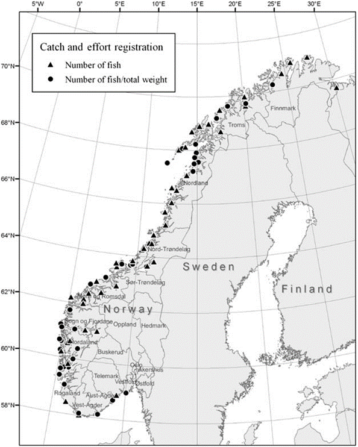

From (Vølstad et al. 2011). Map of tourist-fishing businesses from which catch and effort data were gathered in 2009.

In the absence of any other catch composition data we estimated the total demersal catch, and the mackerel catch for the area north of 62N in each year from the 2009 data, assuming a constant ratio of all demersal species : cod of 1.857, and mackerel : cod of 0.0086 (Table 7).

Table 6: Coastal cod catch from ICES areas 1 and 2 by tourist businesses recreational fishers. Between 1984 and 2009 the tourist only catch is from ICES ((2010); Table 2.1c), while the combined tourist + recreation catch (1984-2019) is from ICES ((2020); Table 2.1e). Between 2010 ad 2019 the tourist catch (grey shaded) is assumed to increase at 5% per year (ICES 2020). The recreation-only catch is the difference between the total and tourism

| Year | Combined tourism & recreation catch (tonnes) | Tourist catch (tonnes) | Implied recreation catch (tonnes) = total- tourist |
| --- | --- | --- | --- |
| 2010 | 12700 | 1890.0 | 10810.0 |
| 2011 | 12700 | 1985.0 | 10716.0 |
| 2012 | 12700 | 2084.0 | 10616.0 |
| 2013 | 12700 | 2188.0 | 10512.0 |
| 2014 | 12700 | 2297.0 | 10403.0 |
| 2015 | 12700 | 2412.0 | 10288.0 |
| 2016 | 12700 | 2533.0 | 10167.0 |
| 2017 | 12700 | 2659.0 | 10041.0 |
| 2018 | 12700 | 2792.0 | 9908.0 |
| 2019 | 12700 | 2932.0 | 9768.0 |
| Mean | 12700 | 2377.2 | 10322.9 |

Table 7: Data for the 2009 national survey of tourist recreational fishing in Norway from (Vølstad et al. 2011), Table 2. The data were presented for two regions, North and South of 62N. The additional column shown here for the Finmark and Troms area is a 21.57% subset of the data for “North of 62N” based the proportion (11 out of 52) of the tourist businesses in “North of 62N” which were located in these administrative areas. Values are the annual catch weight in tonnes.

| Measure | North of 62N | South of 62N | Estimated Finmark and Troms regions (21.57% of “North of 62N”) | Other regions (78.43% of “North of 62N”) | ...6 | 0.65384615384615385 |
| --- | --- | --- | --- | --- | --- | --- |
| Cod | 1586.00000 | 27.000 | 335.50000 | 1.243900e+03 | NA | NA |
| Haddock | 115.10000 | 9.400 | 24.30000 | 9.027293e+01 | NA | NA |
| Saithe | 825.20000 | 208.000 | 174.60000 | 6.472044e+02 | NA | NA |
| Pollack | 81.10000 | 21.400 | 17.20000 | 6.360673e+01 | NA | NA |
| Hallibut | 79.70000 | 0.200 | 16.90000 | 6.250871e+01 | NA | NA |
| Mackerel | 13.60000 | 54.400 | 2.90000 | 1.066648e+01 | NA | NA |
| Ling | 68.50000 | 40.400 | 14.50000 | 5.372455e+01 | NA | NA |
| Tusk | 173.70000 | 15.900 | 36.70000 | 1.362329e+02 | NA | NA |
| Wolffish | 15.30000 | 0.300 | 3.20000 | 1.199979e+01 | NA | NA |
| Total weight | 2958.20000 | 377.000 | 625.80000 | 2.320116e+03 | NA | NA |
| Total weight excl. mackerel | 2944.60000 | 322.600 | 622.90000 | 2.309450e+03 | NA | NA |
| Ratio of total demersal guild : cod | 1.85700 | 11.948 | 1.85700 | 1.856620e+00 | NA | NA |
| Ratio of mackerel : cod | 0.00858 | 2.015 | 0.00858 | 8.575032e-03 | NA | NA |

| Year | Tourist.Cod | Tourist.Total Demersal | Tourist.Mackerel | Recreation.Cod | Recreation.Total Demersal | Recreation.Mackerel | Combined.Total Demersal | Combined.Mackerel |
| --- | --- | --- | --- | --- | --- | --- | --- | --- |
| 1984 | 0 | 0 | 0 | 2479 | 4603 | 21 | 4603 | 21 |
| 1985 | 0 | 0 | 0 | 2498 | 4638 | 21 | 4638 | 21 |
| 1986 | 0 | 0 | 0 | 2516 | 4673 | 22 | 4673 | 22 |
| 1987 | 0 | 0 | 0 | 2516 | 4673 | 22 | 4673 | 22 |
| 1988 | 0 | 0 | 0 | 2535 | 4707 | 22 | 4707 | 22 |
| 1989 | 19 | 35 | 0 | 2535 | 4707 | 22 | 4742 | 22 |
| 1990 | 19 | 35 | 0 | 2684 | 4984 | 23 | 5019 | 23 |
| 1991 | 19 | 35 | 0 | 2833 | 5261 | 24 | 5296 | 24 |
| 1992 | 19 | 35 | 0 | 2982 | 5538 | 26 | 5573 | 26 |
| 1993 | 19 | 35 | 0 | 2740 | 5088 | 23 | 5123 | 24 |
| 1994 | 19 | 35 | 0 | 2721 | 5053 | 23 | 5088 | 23 |
| 1995 | 37 | 69 | 0 | 2703 | 5019 | 23 | 5088 | 23 |
| 1996 | 37 | 69 | 0 | 2665 | 4950 | 23 | 5019 | 23 |
| 1997 | 56 | 104 | 0 | 2647 | 4915 | 23 | 5019 | 23 |
| 1998 | 56 | 104 | 0 | 2665 | 4950 | 23 | 5053 | 23 |
| 1999 | 75 | 138 | 1 | 2516 | 4673 | 22 | 4811 | 22 |
| 2000 | 93 | 173 | 1 | 2442 | 4534 | 21 | 4707 | 22 |
| 2001 | 130 | 242 | 1 | 2367 | 4396 | 20 | 4638 | 21 |
| 2002 | 149 | 277 | 1 | 2386 | 4430 | 20 | 4707 | 22 |
| 2003 | 168 | 312 | 1 | 2423 | 4500 | 21 | 4811 | 22 |
| 2004 | 205 | 381 | 2 | 2293 | 4257 | 20 | 4638 | 21 |
| 2005 | 224 | 415 | 2 | 2237 | 4153 | 19 | 4569 | 21 |
| 2006 | 242 | 450 | 2 | 2181 | 4050 | 19 | 4500 | 21 |
| 2007 | 280 | 519 | 2 | 2143 | 3980 | 18 | 4500 | 21 |
| 2008 | 298 | 554 | 3 | 2088 | 3877 | 18 | 4430 | 20 |
| 2009 | 336 | 623 | 3 | 2032 | 3773 | 17 | 4396 | 20 |
| 2010 | 352 | 654 | 3 | 2015 | 3742 | 17 | 4396 | 20 |
| 2011 | 370 | 687 | 3 | 1997 | 3709 | 17 | 4396 | 20 |
| 2012 | 388 | 721 | 3 | 1979 | 3675 | 17 | 4396 | 20 |
| 2013 | 408 | 757 | 3 | 1959 | 3638 | 17 | 4396 | 20 |
| 2014 | 428 | 795 | 4 | 1939 | 3601 | 17 | 4396 | 20 |
| 2015 | 450 | 835 | 4 | 1918 | 3561 | 16 | 4396 | 20 |
| 2016 | 472 | 877 | 4 | 1895 | 3519 | 16 | 4396 | 20 |
| 2017 | 496 | 920 | 4 | 1871 | 3475 | 16 | 4396 | 20 |
| 2018 | 520 | 967 | 4 | 1847 | 3429 | 16 | 4396 | 20 |
| 2019 | 546 | 1015 | 5 | 1821 | 3381 | 16 | 4396 | 20 |
| Mean 2011-2019 | 453 | 842 | 4 | 1914 | 3554 | 16 | 4396 | 20 |

### EU (including UK) fishing catch and activity in the Norwegian Sea

The European commission’s Scientific, Technical, and Economic Committee for Fisheries (STECF) provide spatially explicit datasets on annual fish catch (https://stecf.jrc.ec.europa.eu/dd/fdi/spatial-landmap) and fishing effort (https://stecf.jrc.ec.europa.eu/dd/fdi/spatialeff- map) by the fishing fleets of member states around the world. Data is available for the years 2015-2018 by fishing gear. The landings dataset is further resolved by species caught. The data processing steps were similar to those described above for the Norwegian fishing fleet. 1. Once again we corrected landings and fishing effort according to the overlap between STECF reporting areas and our model domain. We summarised the data available from global fishing watch from 2012-2016 into average annual 0.01° grids of total yearly fishing activity for mobile and static gears. We intersected the polygons representing STECF reporting areaa, and the StathE2E model domain, and calculated the total mobile and static gear activity within each polygon according to GFW. We then calculated the proportion of mobile and static gear activity for each STECF area code which fell within the StrathE2E model domain and scaled the values reported by STECF. 2. We aggregated gears and species to StrathE2E gear types and guilds. Data was totaled within years, then averaged across the target time period. Effort and landings were summed by gear and guild within years. 3. We used the same approach to calculate the proportion of fishing effort across the 8 StrathE2E habitat types. Instead of the intersection between the StrathE2E model domain and the STECF reporting regions, we intersected the Norwegian Sea habitats with STECF reporting regions (Figure 2). We then calculated the proportion of Global Fishing Watch gear activity for each reporting region which fell within the StrathE2E habitats. 4. Corrected landings were summed spatially and saved as a matrix by gear and guild. Corrected effort was totaled across area codes and saved by StrathE2E gear types. Corrected effort was also totaled across area codes and saved as a matrix by gears and habitats.

### International fishing catch and activity in the Norwegian Sea

Though we have spatially explicit data of fisheries landings and effort for the Norwegian and EU fishing fleet in Norwegian Sea, a sizable portion of activity is missing. The Russian, Icelandic and Faroese and other international fishing fleet that we will call “International fishing fleet” have a notable presence in the Norwegian Sea according to ICES (A. ICES 2022). Unfortunately the ICES data does not resolve landings by gear used, and the spatial resolution of landings is coarse.

#### International Catch by gear and guild

To approximate international catch we use the ICES data on fisheries landings from our internal database to calculate an inflation factor. 1. We divide the total weight landed per guild in area 27.2.a by the total international catch in the same area. 2. We sum the Norwegian and EU matrices described above, and multiply by the ICES correction factor per guild. This assumes the International fishing fleet has a distribution of fishing gears similar to the combined EU and Norwegian fishing fleet. 3. Kelp harvesting, Dredge fishing, and the tourist and recreational catch was added to the international matrix after the application of the inflation factor.

#### International effort by gear

To approximate international catch we use the GFW data (Kroodsma et al. 2018) to calculate an inflation factor. 1. We divide the total effort by mobile and static gears by the total international effort represented by flags other than Russia. The appropriate correction factors were matched to StrathE2E gear types based on wthe GFW gears. The following gears were not inflated as they are unique to the Norwegian fleet: Harpoons, Dredge, Kelp harvesting, Recreational. 2. We sum the Norwegian and EU effort vectors described above, and multiply by the GFW correction factor per gear. 3. The tourist, recreational (described above), harpoons, dredge, kelp harvesting effort were added to the international effort after the application of the inflation factor. 4. Annual hours of fishing effort were then converted into to daily effort in s/m2.

### Discard rates

Discard rates were calculated as the ratio of discarded weight to caught weight for each gear and guild.

#### EU fleet discards

STECF provides a record of fisheries discards “FDI-catches-by-country” for the years 2015-2019. These records are at a coarser resolution than the data used above for landings and fishing effort. We limited the dataset to records from FAO fisheries area 27.2.A, to represent the Norwegian Sea. Some entries are marked as confidential when there is a risk of identifying specific vessels. For entries with known discard quantities, we calculated the discard rates as $discard/(landings+discard)$ and summarised to mean discard rates for StrathE2E gear classes and guilds over the whole time period. Unrepresented combinations of gear and guild were automatically assigned a discard rate of 0. We manually set the discard rates for a number of guilds which are only targeted by a single specialist gear to 1. These were cetaceans, pinnipeds, birds, and macrophytes. Harpoons for cetaceans, and kelp harvesting for macrophytes were then assigned a discard rate of 0.

#### Additional bycatch in the Norwegian Sea

##### Bycatch of cetaceans

The ICES Fisheries Overview of the Norwegian Sea Ecoregion (A. ICES 2022) (page 21) states that “Marine mammals that get entangled in fishing gear may drown or die later from injuries or from being partially entangled in parts from the fishing gear. In the Norwegian Sea, the largest bycatch of marine mammals occurs in the bottom set gillnet fisheries targeting cod and monkfish. Harbour porpoises, harbour seals, and grey seals are frequently killed in these fisheries. Around 2000 harbour porpoises are taken in Norwegian commercial fisheries each year.” and “Bycatch of larger whales are less frequent. The number of bycatches of sperm whale and humpback whale in Norwegian fisheries is usually fewer than ten individuals annually (per species), and many of these are released alive.”. NAMMCO considers the bycatch of white-sided dolphin to be “negligible to non-existent” (https://nammco.no/atlantic-white-sided-dolphin-2/#1475845220355-579f0567-e59c) and the extent of bycatch of white beaked dolphin being “unknown” (https://nammco.no/white-beaked-dolphin/#1475845220355-579f0567-e59c). We thus choose to use the available data for porpoises as an estimation of the bycatch of cetaceans in the Norwegian Sea.

##### Bycatch of pinnipeds

The ICES Fisheries Overview of the Norwegian Sea Ecoregion (A. ICES 2022) (page 21) states that “In the Norwegian Sea, the largest bycatch of marine mammals occurs in the bottom set gillnet fisheries targeting cod and monkfish. Harbour porpoises, harbour seals, and grey seals are frequently killed in these fisheries. (…) Surveys of grey seals have shown a 50–60% reduction in pup production between 2007 and 2015 in mid-Norway, probably as a result of increased bycatches in gillnet fisheries for monkfish and cod. Bycatch of seals in coastal areas is uncertain (owing to unreliable species identification) but believed to be in the order of around 200 individuals per species.

For the pinnipeds, we used discards data from gillnets fisheries from (A. Moan and Bjørge 2021). We used data of harbour and grey seals on the coast of Norway from the region 2 of Figure 5). The data used estimates based on data from 2015 for harbour seals and for 2011 and 2017 for the grey seals (Table 2). We used data from (Pedersen et al. 2021) to multiply the number of idividuals by their mean weight and then divided by the surface area of the whole domain to obtain bycatch in $t \cdot m^{-2}$.

We summed the discard weights for each gear and guilds as $discards/(landings+discards)$ and summarised to mean discard rates for StrathE2E gear classes and guilds .

##### Bycatch of birds

The bycatch of birds was estimated using the estimations from (Hilde Sofie Fantoft and Nedreaas 2021) for the year 2018. The data was used to estimate the number of birds bycatch from gillnets fisheries. We used the table 6.1 of the report (Table 3). We multiplied the number of birds bycatched by their mean weight from (Pedersen et al. 2021) to obtain a yearly mean weight of birds bycatch by statistical area. We kept only the statistical areas 00 and 05 . We then divided the weight by the surface area of each statistical area to obtain estimations of bycatch in $t \cdot m^{-2}$.

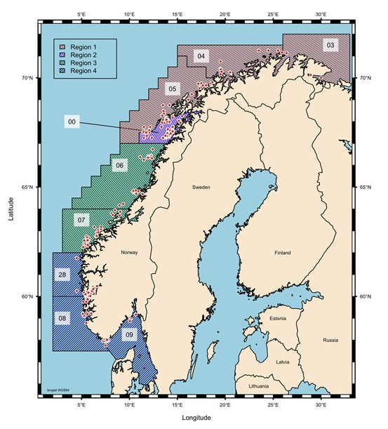

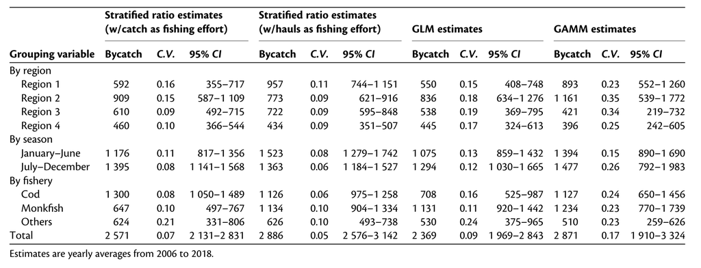

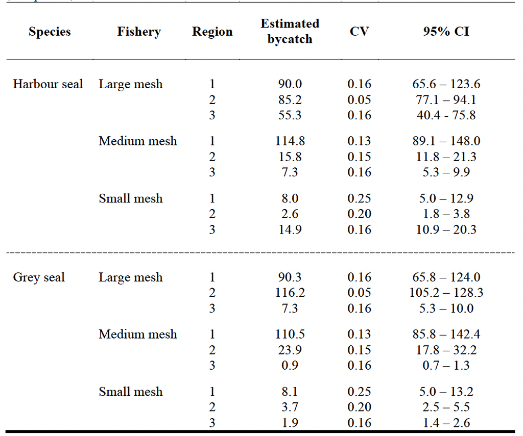

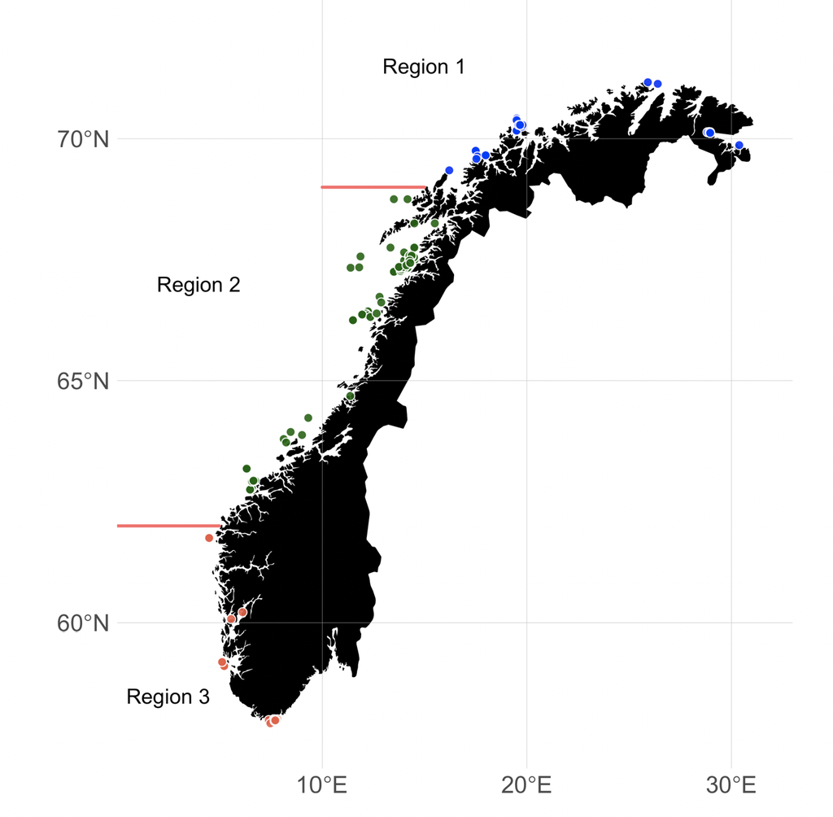

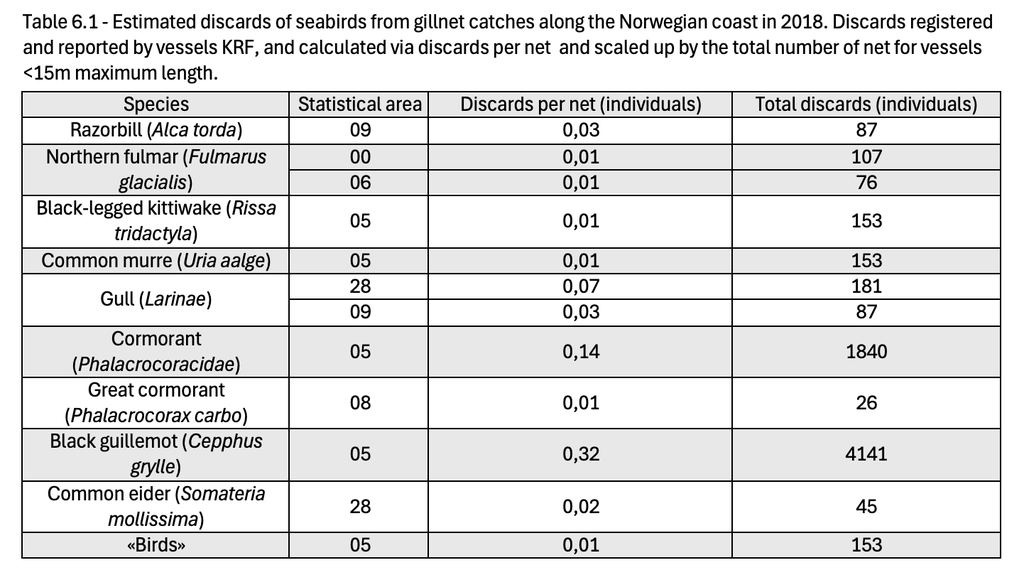

### Losses by processing-at-sea rates

Processing-at-sea refers to the practice on some types of vessels of eviscerating selected proportions of the catch and returning the viscera to the sea as offal. To calculate the processing-at-sea rates, we used data from the Norwegian directorate for fisheries landings which reports both post-processed weight (produktvekt) and estimated round weight (Rundvekt). To obtain the part of the landings being rejected at sea as offal, we calculated $(Round weight-post-processed weight)/Round weight$. We thus obtainend the offal rates for each gear and guild for the Norwegian fleet. We considered the other fleets to have a similar ratio of offal to round weight as the Norwegian fleet.

### Final processing

1. Total catch by gear and guild was calculated by inflating landings according to EU discard rates before adding additional known discarded weight (described above for cetaceans, birds, planktivores and demersal fish).
2. Discarded weight was calculated as catch - landings.
3. Demersal non quota and quota limited were combined into a single Demersal guild for catch, landings and discards.
4. New discard rates reflecting all data sources were calculated as discarded weight / caught weight. When catch was 0 discard rates were set to 1 except for kelp harvesters which were assigned a discard rate of 0 for macrophytes.
5. Fishing power was calculated as catch / activity per gear.

# Target Data

## Annual target data

The independent data of annual-indices of the ecosystem were taken from various sources and translated to $mMN \cdot m^{-2} \cdot y^{-1}$ using the conversion rates used in (M. R. Heath et al. 2021) (Table 11).

- The annual total primary production and chlorphyll concentrations was taken from COPERNICUS-GlobColour assuming redfield ratio (European Union-Copernicus Marine Service 2022).
- The annual production of zooplankton was estimated from a simulation using the NORWECOM (Skogen et al. 2018) model ran in January 2025 by Morten Skogen.
- The annual productions of fish, birds, cetaceans and pinnipeds were estimated from the values of (Skaret and Pitcher 2016).
- The annual productions of benthos were estimated from (Blanchard, Pinnegar, and Mackinson 2002).
- The estimations of consumptions were taken from the data of (Skaret and Pitcher 2016), (Pedersen et al. 2021), (Christensen et al. 2001) and (Blanchard, Pinnegar, and Mackinson 2002).
- The landings and discards were calculated on the same way described in section Fishing fleet.
- The Production/Biomass ratios were calculated from (Blanchard, Pinnegar, and Mackinson 2002), (Christensen et al. 2001), (Mackinson and Daskalov 2008) and (Fredriksen et al. 1995).
- The other metabolic ratios for macrophytes were taken from (Broch and Slagstad 2012)
- Denitrification estimated from (McTigue et al. 2016)
- Nitrate concentration in sediment from (Laverick, Speirs, and Heath 2022)
- Nitrate concentration in water column from (Mork et al. 2024)
- Bycatch of birds from (Bærum et al. 2019)
- Bycatch of seals and cetaceans from (A. G. Moan 2016)

## Monthly target data

Monthly chlorophyll concentrations were taken from COPERNICUS-GlobColour assuming redfield ratio (European Union-Copernicus Marine Service 2022).

Table 11: Conversion from g to mMN.

| Units | mMN_per_gWW |
| --- | --- |
| Suspended_detritus | 1.2578616 |
| Ice_detritus | 1.2578616 |
| Sediment_detritus | 1.2578616 |
| Discards | 1.2578616 |
| Corpses | 1.2578616 |
| Macrophytes | 2.0700000 |
| Phytoplankton | 1.2578616 |
| Omnivorous_zooplankton | 1.2578616 |
| Carnivorous_zooplanton | 1.2578616 |
| Larvae_susp_deposit_feeding_benthos | 1.2578616 |
| Susp_deposit_feeding_benthos | 0.5031446 |
| Larvae_carn_scav_feeding_benthos | 1.2578616 |
| Carn_scav_feeding_benthos | 1.0062893 |
| Larvae_planktiv_fish | 1.2578616 |
| Planktiv_fish | 2.0377358 |
| Migratory_fish | 2.3144654 |
| Larvae_demersal_fish | 1.2578616 |
| Demersal_fish | 1.2955975 |
| Birds | 2.5157233 |
| Pinnipeds | 2.5157233 |
| Cetaceans | 2.5157233 |

Table 9: Annual-based indices of the state of the ecosystem in the study area for 2010-2019.

| Annual_measure | SD_of_measure | Units | Description | Source |
| --- | --- | --- | --- | --- |
| 787.4671 | 71.3905 | mMN/m2/y | Annual_total_primary_production | Copernicus remote sensing data from OCEANCOLOUR_GLO_BGC_L4_MY_009_104 |
| 309.0000 | 167.0000 | gC/m2/y | Annual_WITHIN_FOREST_NET_production_of_macrophytes | Frigstad et al 2021 |
| 890.0000 | 667.5000 | mMN/m2/y | Annual_ominiv_zooplankton_gross_production | Morten Norwecom |
| 215.0000 | 215.0000 | mMN/m2/y | Annual_carnivorous_zooplankton_gross_production | Morten Norwecom |
| 40.1660 | 40.1660 | mMN/m2/y | Annual_planktivorous_fish_gross_production | Skaret and Pitcher 2016 |
| 0.9016 | 2.0000 | mMN/m2/y | Annual_demersal_fish_gross_production | Skaret and Pitcher 2016 |
| 77.0000 | 77.0000 | mMN/m2/y | Annual_susp/dep_benthos_gross_production | Blanchard_et_al_2002 |
| 7.0000 | 7.0000 | mMN/m2/y | Annual_carn/scan_benthos_gross_production | Blanchard_et_al_2002 |
| 0.0125 | 0.0125 | mMN/m2/y | Annual_net_production_of_birds | Skaret and Pitcher 2016 |
| 0.0345 | 0.0345 | mMN/m2/y | Annual_net_production_of_pinnipeds | Skaret and Pitcher 2016 |
| 0.0169 | 0.0169 | mMN/m2/y | Annual_net_production_of_cetaceans | Skaret and Pitcher 2016 |
| 12.5488 | 9.4116 | mMN/m2/y | Annual_consumption_of_planktivorous_fish_by_fish | Christensen et al 2001 |
| 11.7036 | 8.7777 | mMN/m2/y | Annual_consumption_of_demersal_fish_by_fish | Christensen et al 2001 |
| 14.7680 | 11.0760 | mMN/m2/y | Annual_consumption_of_omniv_zooplankton_by_fish_and_fish_larvae | Dommasnes_et_al_2001 |
| 51.7500 | 38.8125 | mMN/m2/y | Annual_consumption_of_omniv_zooplankton_by_carn_zooplankton | Blanchard_et_al_2002 |
| 44.0331 | 33.0248 | mMN/m2/y | Annual_consumption_of_benthos_by_fish | Pedersen et al 2021 |
| 1.5008 | 1.1256 | mMN/m2/y | Annual_food_consumption_by_birds | Pedersen et al 2021 |
| 0.2500 | 0.2500 | dimensionless | Proportion_planktivorous_fish_in_diet_of_birds | Skaret and Pitcher 2016 |
| 0.2120 | 0.2120 | dimensionless | Proportion_demersal_fish_in_diet_of_birds | Skaret and Pitcher 2016 |

Table 9 Continued.

| Annual_measure | SD_of_measure | Units | Description | Source |
| --- | --- | --- | --- | --- |
| 0.1951 | 0.1951 | dimensionless | Proportion_migratory_fish_in_diet_of_birds | Skaret and Pitcher 2016 |
| 0.0400 | 0.0300 | dimensionless | Proportion_discards_in_diet_of_birds | Dommasnes_et_al_2001 |
| 3.5449 | 3.5449 | mMN/m2/y | Annual_food_consumption_by_pinnipeds | Skaret and Pitcher 2016 |
| 0.1050 | 0.1050 | dimensionless | Proportion_planktivorous_fish_in_diet_of_pinnipeds | Skaret and Pitcher 2016 |
| 0.2305 | 0.2305 | dimensionless | Proportion_demersal_fish_in_diet_of_pinnipeds | Skaret and Pitcher 2016 |
| 0.3351 | 0.3351 | dimensionless | Proportion_migratory_fish_in_diet_of_pinnipeds | Skaret and Pitcher 2016 |
| 4.7185 | 4.7185 | mMN/m2/y | Annual_food_consumption_by_cetaceans | Skaret and Pitcher 2016 |
| 0.2843 | 0.2843 | dimensionless | Proportion_planktivorous_fish_in_diet_of_cetaceans | Skaret and Pitcher 2016 |
| 0.0547 | 0.0547 | dimensionless | Proportion_demersal_fish_in_diet_of_cetaceans | Skaret and Pitcher 2016 |
| 0.3442 | 0.3442 | dimensionless | Proportion_migratory_fish_in_diet_of_cetaceans | Skaret and Pitcher 2016 |
| 0.9320 | 0.2330 | mMN/m2/y | Annual_planktivorous_fish_landings_(live_weight) | Fiskeridirektoratet |
| 0.2410 | 0.0602 | mMN/m2/y | Annual_demersal_fish_landings_(live_weight) | Fiskeridirektoratet |
| 0.6110 | 0.1527 | mMN/m2/y | Annual_migratory_fish_landings_(live_weight) | Fiskeridirektoratet |
| 0.0003 | 0.0001 | mMN/m2/y | Annual_susp/dep_benthos_landings_(live_weight) | Fiskeridirektoratet |
| 0.0000 | 0.0000 | mMN/m2/y | Annual_carn/scav_benthos_landings_(live_weight) | Fiskeridirektoratet |
| 0.0000 | 0.0000 | mMN/m2/y | Annual_carn_zooplankton_landings_(live_weight) | Norwegian_Fisheries_Directorate/STECF/ICES_FAO |
| 0.3027 | 0.0757 | mMN/m2/y | Annual_macrophyte_landings_(live_weight) | Dehnhard et al 2024 NINA Report 2502 - 167460t per year kelp plus ascophyllum |
| 0.6500 | 0.3250 | /y | Annual_CARBON_gross_PB_ratio_of_macrophytes | Sjøtun_et_al_1995/Dommasnes et al. 2001 |
| 10.0000 | 5.0000 | /y | Annual_gross_PB_ratio_larvae_of_susp/dep_benthos | Mackinson_and_Daskalov_2007 |

Table 9 Continued.

| Annual_measure | SD_of_measure | Units | Description | Source |
| --- | --- | --- | --- | --- |
| 10.0000 | 5.0000 | /y | Annual_gross_PB_ratio_larvae_of_carn/scav_benthos | Mackinson_and_Daskalov_2007 |
| 6.4400 | 3.2200 | /y | Annual_gross_PB_ratio_susp/dep_feeding_benthos | Blanchard_et_al_2002 |
| 2.4200 | 1.2100 | /y | Annual_gross_PB_ratio_carn/scav_feeding_benthos | Blanchard_et_al_2002 |
| 7.3478 | 3.6700 | /y | Annual_gross_PB_ratio_omniv_zooplankton | Dommasnes_et_al_2001 |
| 1.9581 | 0.9790 | /y | Annual_gross_PB_ratio_carniv_zooplankton | Dommasnes_et_al_2001 |
| 4.0000 | 2.0000 | /y | Annual_gross_PB_ratio_larvae_of_planktivorous_fish | Mackinson_and_Daskalov_2007 |
| 4.0000 | 2.0000 | /y | Annual_gross_PB_ratio_larvae_of_demersal_fish | Mackinson_and_Daskalov_2007 |
| 1.6068 | 0.8030 | /y | Annual_gross_PB_ratio_planktivorous_fish | Dommasnes_et_al_2001 |
| 0.5377 | 0.2690 | /y | Annual_gross_PB_ratio_demersal_fish | Dommasnes_et_al_2001 |
| 0.6908 | 0.3450 | /y | Annual_gross_PB_ratio_migratory_fish | Dommasnes_et_al_2001 |
| 1.0000 | 0.5000 | /y | Annual_net_PB_ratio_birds | Dommasnes_et_al_2001 |
| 0.1430 | 0.0715 | /y | Annual_net_PB_ratio_pinnipeds | Dommasnes_et_al_2001 |
| 0.0356 | 0.0178 | /y | Annual_net_PB_ratio_cetaceans | Dommasnes_et_al_2001 |
| 0.3900 | 0.3900 | dimensionless | Annual_average_proportion_of_macrophyte_C_uptake_which_is_exuded | Broch and Slagstad, 2012 |
| 0.1200 | 0.1200 | dimensionless | Annual_average_molar_NC_ratio_of_macrophytes | Broch and Slagstad, 2012 |
| 90.7000 | 90.7000 | mMN/m2/y | Annual_denitrification | McTigue_et_al_2016 |
| 0.0320 | 0.0320 | dimensionless | Proportion_of_demersal_fish_catch_discarded | Norwegian_Fisheries_Directorate/STECF/ICES_FAO |
| 0.0353 | 0.0353 | %N(gN/g_dry_sed) | Annual_average_organic_N_content_of_sand_gs_0.25mm_(0.19-0.43mm) | Laverick_et_al_submitted |
| 0.1361 | 0.1361 | %N(gN/g_dry_sed) | Annual_average_organic_N_content_of_mud_gs_0.12mm_(0.03-0.07mm) | Laverick_et_al_submitted |

Table 9 Continued.

[output not shown]

Table 10: Monthly-based indices of the state of the ecosystem in the study area for 2010-2019.

| Month | Variable | median | lower_centile | upper_centile | Units | Comments |
| --- | --- | --- | --- | --- | --- | --- |
| Jan | surface_chlorophyll | 0.0000 | 0.0000 | 0.0000 | mgm3 | Copernicus remote sensing data from OCEANCOLOUR_GLO_BGC_L4_MY_009_104 for Norwegian_Basin_MA 2010-2019 |
| Feb | surface_chlorophyll | 0.1378 | 0.1264 | 0.1507 | mgm3 | Copernicus remote sensing data from OCEANCOLOUR_GLO_BGC_L4_MY_009_104 for Norwegian_Basin_MA 2010-2019 |
| Mar | surface_chlorophyll | 0.1754 | 0.1666 | 0.1951 | mgm3 | Copernicus remote sensing data from OCEANCOLOUR_GLO_BGC_L4_MY_009_104 for Norwegian_Basin_MA 2010-2019 |
| Apr | surface_chlorophyll | 0.2082 | 0.1952 | 0.2535 | mgm3 | Copernicus remote sensing data from OCEANCOLOUR_GLO_BGC_L4_MY_009_104 for Norwegian_Basin_MA 2010-2019 |
| May | surface_chlorophyll | 0.4442 | 0.3656 | 0.5623 | mgm3 | Copernicus remote sensing data from OCEANCOLOUR_GLO_BGC_L4_MY_009_104 for Norwegian_Basin_MA 2010-2019 |
| Jun | surface_chlorophyll | 0.6325 | 0.5122 | 0.6942 | mgm3 | Copernicus remote sensing data from OCEANCOLOUR_GLO_BGC_L4_MY_009_104 for Norwegian_Basin_MA 2010-2019 |
| Jul | surface_chlorophyll | 0.4798 | 0.4330 | 0.5793 | mgm3 | Copernicus remote sensing data from OCEANCOLOUR_GLO_BGC_L4_MY_009_104 for Norwegian_Basin_MA 2010-2019 |
| Aug | surface_chlorophyll | 0.4097 | 0.3869 | 0.5949 | mgm3 | Copernicus remote sensing data from OCEANCOLOUR_GLO_BGC_L4_MY_009_104 for Norwegian_Basin_MA 2010-2019 |
| Sep | surface_chlorophyll | 0.5365 | 0.4679 | 0.5901 | mgm3 | Copernicus remote sensing data from OCEANCOLOUR_GLO_BGC_L4_MY_009_104 for Norwegian_Basin_MA 2010-2019 |
| Oct | surface_chlorophyll | 0.3755 | 0.3059 | 0.4143 | mgm3 | Copernicus remote sensing data from OCEANCOLOUR_GLO_BGC_L4_MY_009_104 for Norwegian_Basin_MA 2010-2019 |
| Nov | surface_chlorophyll | 0.0606 | 0.0486 | 0.0701 | mgm3 | Copernicus remote sensing data from OCEANCOLOUR_GLO_BGC_L4_MY_009_104 for Norwegian_Basin_MA 2010-2019 |
| Dec | surface_chlorophyll | 0.0000 | 0.0000 | 0.0000 | mgm3 | Copernicus remote sensing data from OCEANCOLOUR_GLO_BGC_L4_MY_009_104 for Norwegian_Basin_MA 2010-2019 |

# End

## References

Anon. 2005. “Har Turistfisket Innvirkning på Bestanden Av Kysttorsk.” Essens Management.

Bachiller, Eneko, Georg Skaret, Leif Nøttestad, and Aril Slotte. 2016. “Feeding Ecology of Northeast Atlantic Mackerel, Norwegian Spring-Spawning Herring and Blue Whiting in the Norwegian Sea.” *PLOS ONE* 11 (February): e0149238. https://doi.org/10.1371/journal.pone.0149238.

Bærum, Kim Magnus, Tycho Anker-Nilssen, Signe Christensen-Dalsgaard, Kirstin Fangel, Tom Williams, and Jon Helge Vølstad. 2019. “Spatial and Temporal Variations in Seabird Bycatch: Incidental Bycatch in the Norwegian Coastal Gillnet-Fishery.” *PLOS ONE* 14 (3): e0212786. https://doi.org/10.1371/journal.pone.0212786.

Bakke, Snorre. 2019. “Life History and Distribution of the Edible Crab (Cancer Pagurus) in Norway - Effect of Temperature and Other Environmental Parameters at High Latitudes.” Doctoral Thesis, UiT The Arctic University of Norway.

Blanchard, Julia, John Pinnegar, and Steven Mackinson. 2002. “Exploring Marine Mammal-Fishery Interactions Using ’Ecopath with Ecosim’: Modelling the Barents Sea Ecosystem.” *Science Series Technical Report* 117 (January).

Broch, Ole Jacob, and Dag Slagstad. 2012. “Modelling Seasonal Growth and Composition of the Kelp Saccharina Latissima.” *Journal of Applied Phycology* 24 (4): 759–76. https://doi.org/10.1007/s10811-011-9695-y.

Brooke, Sandra, and Johanna Järnegren. 2013. “Reproductive Periodicity of the Scleractinian Coral Lophelia Pertusa from the Trondheim Fjord, Norway.” *Marine Biology* 160 (1): 139–53. https://doi.org/10.1007/s00227-012-2071-x.

Buhl-Mortensen, Lene, Hanne Hodnesdal, and Terje Thorsnes, eds. 2015. *The Norwegian Sea Floor: New Knowledge from MAREANO for Ecosystem-Based Management*. 1. edition. Norway? MAREANO.

Christensen, Villy, Bjørnar Ellertsen, Cecilie Kvamme, Webjørn Melle, Leif Nøttestad, and Sigurd Tjelmeland. 2001. “An Ecopath Model for the Norwegian Sea and Barents Sea.” *Fisheries Impacts on North Atlantic Ecosystems: Models and Analyses. Fisheries Centre Research* 9 (January).

Clegg, Thomas L., Edvin Fuglebakk, and Kotaro Ono. 2023. “Evaluating Assumptions Behind Design-Based Estimators for Unreported Catches.” *Fisheries Research* 263 (July): 106686. https://doi.org/10.1016/j.fishres.2023.106686.

dos Santos Schmidt, T C, A Slotte, A H Olafsdottir, L Nøttestad, T Jansen, J A Jacobsen, S Bjarnason, et al. 2024. “Poleward Spawning of Atlantic Mackerel (Scomber Scombrus) Is Facilitated by Ocean Warming but Triggered by Energetic Constraints.” *ICES Journal of Marine Science* 81 (3): 600–615. https://doi.org/10.1093/icesjms/fsad098.

Eikefjord, Mathilde Bryn. 2023. “A Comparative Study of the Spawning Phenology of Cod (Gadus Morhua), Saithe (Pollachius Virens), and Haddock (Melanogrammus Aeglefinus): A Geographical Perspective Along the Norwegian Coast.” Master’s thesis, The University of Bergen.

Ekerhovd, Nils-Arne. 2010. “The Stability and Resilience of Management Agreements on Climate-Sensitive Straddling Fishery Resources: The Blue Whiting (Micromesistius Poutassou) Coastal State Agreement.” *Canadian Journal of Fisheries and Aquatic Sciences* 67 (February): 534–52. https://doi.org/10.1139/F09-195.

European Union-Copernicus Marine Service. 2022. “Global Ocean Colour (Copernicus-GlobColour), Bio-Geo-Chemical, L3 (Daily) from Satellite Observations (1997-Ongoing).” Mercator Ocean International. https://doi.org/10.48670/MOI-00280.

Fredriksen, Stein, Kjersti Sjøtun, Tor Eiliv Lein, and Jan Rueness. 1995. “Spore Dispersal in Laminaria Hyperborea (Laminariales, Phaeophyceae).” *Sarsia* 80 (1): 47–53. https://doi.org/10.1080/00364827.1995.10413579.

Garcia, Théo, Benjamin Planque, Per Arneberg, Bjarte Bogstad, Øystein Skagseth, and Maik Tiedemann. 2021. “An Appraisal of the Drivers of Norwegian Spring-Spawning Herring (Clupea Harengus) Recruitment.” *Fisheries Oceanography* 30 (2): 159–73. https://doi.org/10.1111/fog.12510.

Gohin, F. 2011. “Annual Cycles of Chlorophyll-*a*, Non-Algal Suspended Particulate Matter, and Turbidity Observed from Space and in-Situ in Coastal Waters.” *Ocean Science* 7 (5): 705–32. https://doi.org/10.5194/os-7-705-2011.

Hallenstvedt, Abraham. 2004. “Fritidsfiske i Sjøen 2003.” Norges Fiskerihøgskole/Universitetet i Tromsø.

Hamed, Imen, Dionysios Tsoukalas, Anita Nordeng Jakobsen, Junjie Zhang, Alexandros G. Asimakopoulos, Kyyas Seyitmuhammedov, and Jørgen Lerfall. 2024. “Edible Sea Urchins *Echinus* *Esculentus* from Norwegian Waters- Effect of Season on Nutritional Quality and Chemical Contaminants.” *Food Chemistry* 447 (July): 139032. https://doi.org/10.1016/j.foodchem.2024.139032.

Heath, Michael R. 2012. “Ecosystem Limits to Food Web Fluxes and Fisheries Yields in the North Sea Simulated with an End-to-End Food Web Model.” *Progress in Oceanography*, End-to-End Modeling: Toward Comparative Analysis of Marine Ecosystem Organization, 102 (September): 42–66. https://doi.org/10.1016/j.pocean.2012.03.004.

Heath, Michael R., Douglas C. Speirs, Ian Thurlbeck, and Robert J. Wilson. 2021. “StrathE2E2: An r Package for Modelling the Dynamics of Marine Food Webs and Fisheries.” *Methods in Ecology and Evolution* 12 (2): 280–87. https://doi.org/10.1111/2041-210X.13510.

Heath, M., R. Wilson, and Douglas C Speirs. 2015. “Modelling the Whole-Ecosystem Impacts of Trawling. A Study Commissioned by Fisheries Innovation Scotland (FIS).”

Hersbach, Hans, Bill Bell, Paul Berrisford, Shoji Hirahara, András Horányi, Joaquín Muñoz-Sabater, Julien Nicolas, et al. 2020. “The ERA5 Global Reanalysis.” *Quarterly Journal of the Royal Meteorological Society* 146 (730): 1999–2049. https://doi.org/10.1002/qj.3803.

Hilde Sofie Fantoft, Berg, and Kjell Harald Nedreaas. 2021. “Estimering av utkast i norsk kystfiske med garn - 2012-2018.” *95*.

Holst, Jens Christian, Ingolf Røttingen, and Webjørn Melle. 2004. “The Herring.” In *The Norwegian Sea Ecosystem*, 203–26. Skjodal.

Huitfeldt Aspelund, Miranda, Thomas L. Clegg, and Kjell. H. Nedreaas. 2024. “Discard Estimates in the Norwegian Offshore Longline Fisheries.”

ICES. 2010. “Report of the Arctic Fisheries Working Group (AFWG).” Report. ICES Expert Group reports (until 2018). https://doi.org/10.17895/ices.pub.19280591.v1.

———. 2020. “Arctic Fisheries Working Group (AFWG).” Report. ICES Scientific Reports. https://doi.org/10.17895/ices.pub.6050.

ICES, Advice. 2022. “Norwegian Sea Ecoregion – Fisheries Overview.” Report. ICES Advice: Fisheries Overviews. https://doi.org/10.17895/ices.advice.21640826.v1.

ICES, WGWIDE. 2020. “Working Group on Widely Distributed Stocks (WGWIDE).” Report. ICES Scientific Reports. https://doi.org/10.17895/ices.pub.7475.

Iversen, Svein A. 2002. “Changes in the Perception of the Migration Pattern of Northeast Atlantic Mackerel During the Last 100 Years.” Report. ICES MSS Vol.215 - 100 years of science under ICES. https://doi.org/10.17895/ices.pub.8877.

———. 2004. “Mackerel and Horse Mackerel.” In *The Norwegian Sea Ecosystem*, 289–300. Skjodal.

James, Philip, and Sten Siikavuopio. 2012. “Understanding the Reproductive Cycle of the Green Sea Urchin Strongylocentrotus Droebachiensis in Norway: A Guide for Fishermen, Aquaculturalists and Researchers.”

Järnegren, Johanna, and Tina Kutti. 2014. “Lophelia Pertusa in Norwegian Waters. What Have We Learned Since 2008?” 1028. *40 s.* Norsk institutt for naturforskning.

Jones, C. D., J. K. Hughes, N. Bellouin, S. C. Hardiman, G. S. Jones, J. Knight, S. Liddicoat, et al. 2011. “The HadGEM2-ES Implementation of CMIP5 Centennial Simulations.” *Geoscientific Model Development* 4 (3): 543–70. https://doi.org/10.5194/gmd-4-543-2011.

Kroodsma, David A., Juan Mayorga, Timothy Hochberg, Nathan A. Miller, Kristina Boerder, Francesco Ferretti, Alex Wilson, et al. 2018. “Tracking the Global Footprint of Fisheries.” *Science* 359 (6378): 904–8. https://doi.org/10.1126/science.aao5646.

Laverick, Jack H., Douglas C. Speirs, and Michael R. Heath. 2022. “Synthetic Shelf Sediment Maps for the Greenland Sea and Barents Sea.” *Geoscience Data Journal* 10 (2): 220–30. https://doi.org/10.1002/gdj3.154.

Mackinson, S, and G Daskalov. 2008. “An Ecosystem Model of the North Sea to Support an Ecosystem Approach to Fisheries Management: Description and Parameterisation.”

McTigue, N. D., W. S. Gardner, K. H. Dunton, and A. K. Hardison. 2016. “Biotic and Abiotic Controls on Co-Occurring Nitrogen Cycling Processes in Shallow Arctic Shelf Sediments.” *Nature Communications* 7 (1): 13145. https://doi.org/10.1038/ncomms13145.

Moan, Andre Grande. 2016. “Bycatch of Harbour Porpoise, Harbour Seal and Grey Seal in Norwegian Gillnet Fisheries.” Master’s thesis.

Moan, André, and Arne Bjørge. 2021. “Bycatch of Coastal Seals in Norwegian Gillnet Fisheries Conducted by Coastal Fishing Vessels.” NAMMCO.

Moan, André, Mette Skern-Mauritzen, Jon Helge Vølstad, and Arne Bjørge. 2020. “Assessing the Impact of Fisheries-Related Mortality of Harbour Porpoise (Phocoena Phocoena) Caused by Incidental Bycatch in the Dynamic Norwegian Gillnet Fisheries.” *ICES Journal of Marine Science* 77 (7-8): 3039–49. https://doi.org/10.1093/icesjms/fsaa186.

Mork, Kjell Arne, Kjell Gundersen, Knut Yngve Børsheim, Giorgio Dall’Olmo, Øystein Skagseth, and Henrik Søiland. 2024. “Primary Production and Respiration in the Norwegian Sea Estimated From Biogeochemical Argo Floats.” *Journal of Geophysical Research: Oceans* 129 (6): e2023JC020568. https://doi.org/10.1029/2023JC020568.

Nøttestad, Leif, Kjell R. Utne, Gumundur J. Óskarsson, Sigurdur . Jónsson, Jan Arge Jacobsen, Øyvind Tangen, Valantine Anthonypillai, et al. 2016. “Quantifying Changes in Abundance, Biomass, and Spatial Distribution of Northeast Atlantic Mackerel ( Scomber Scombrus ) in the Nordic Seas from 2007 to 2014.” *ICES Journal of Marine Science* 73 (2): 359–73. https://doi.org/10.1093/icesjms/fsv218.

Pace, Matthew C., David M. Bailey, David W. Donnan, Bhavani E. Narayanaswamy, Hazel J. Smith, Douglas C. Speirs, William R. Turrell, and Michael R. Heath. 2021. “Modelling Seabed Sediment Physical Properties and Organic Matter Content in the Firth of Clyde.” *Earth System Science Data* 13 (12): 5847–66. https://doi.org/10.5194/essd-13-5847-2021.

Payne, Mark, Afra Egan, Sascha Fässler, Hjálmar Hátún, Jens Holst, Jan Jacobsen, Aril Slotte, and Harald Loeng. 2012. “The Rise and Fall of the NE Atlantic Blue Whiting.” *Marine Biology Research* 8 (June): 475–87. https://doi.org/10.1080/17451000.2011.639778.

Pedersen, Torstein, Nina Mikkelsen, Ulf Lindstrøm, Paul E. Renaud, Marcela C. Nascimento, Marie-Anne Blanchet, Ingrid H. Ellingsen, Lis L. Jørgensen, and Hugues Blanchet. 2021. “Overexploitation, Recovery, and Warming of the Barents Sea Ecosystem During 1950–2013.” *Frontiers in Marine Science* 8 (September). https://doi.org/10.3389/fmars.2021.732637.

Skaret, Georg, and Tony J. Pitcher. 2016. “An Ecopath with Ecosim Model of the Norwegian Sea and Barents Sea Validated Against Time Series of Abundance.” *33 s.*, June.

Skogen, Morten D, Solfrid S Hjøllo, Anne Britt Sandø, and Jerry Tjiputra. 2018. “Future Ecosystem Changes in the Northeast Atlantic: A Comparison Between a Global and a Regional Model System.” Edited by Morgane Travers-Trolet. *ICES Journal of Marine Science* 75 (7): 2355–69. https://doi.org/10.1093/icesjms/fsy088.

Vølstad, J. H., K. Korsbrekke, K. H. Nedreaas, M. Nilsen, G. N. Nilsson, M. Pennington, S. Subbey, and R. Wienerroither. 2011. “Probability-Based Surveying Using Self-Sampling to Estimate Catch and Effort in Norway’s Coastal Tourist Fishery.” *ICES Journal of Marine Science* 68 (8): 1785–91. https://doi.org/10.1093/icesjms/fsr077.

Wilson, Robert J., Douglas C. Speirs, Alessandro Sabatino, and Michael R. Heath. 2018. “A Synthetic Map of the North-West European Shelf Sedimentary Environment for Applications in Marine Science.” *Earth System Science Data* 10 (1): 109–30. https://doi.org/10.5194/essd-10-109-2018.

Yang, Jia, and Hanqin Tian. 2022. “ISIMIP3a N-deposition Input Data.” ISIMIP Repository. https://doi.org/10.48364/ISIMIP.759077.2.